# Ford Go Bike Data Exploration

## Bivariate Exploration

> In this section, investigate relationships between pairs of variables in this dataset.

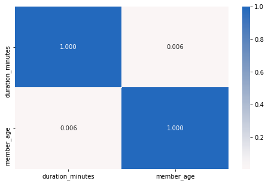

```python
numeric_vars = ['duration_minutes','member_age']
plt.figure(figsize = [8, 5])
sb.heatmap(fordBike[numeric_vars].corr(), annot = True, fmt = '.3f',
           cmap = 'vlag_r', center = 0)
plt.show()
```

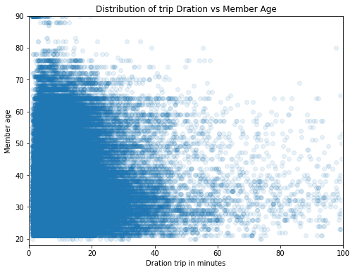

```python
plt.figure(figsize = [8, 6])
plt.scatter(data = fordBike.dropna(), x = 'duration_minutes', y = 'member_age', alpha = 1/10)
plt.title('Distribution of trip Dration vs Member Age')
plt.xlabel('Dration trip in minutes')
plt.ylabel('Member age')
plt.xlim(0, 100)#Remove outliers
plt.ylim(18, 90)
plt.show()
```

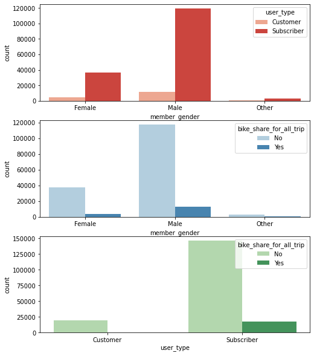

```python
# since there's only three subplots to create, using the full data should be fine.
plt.figure(figsize = [8, 10])

plt.subplot(3, 1, 1)
sb.countplot(data = fordBike, x = 'member_gender', hue = 'user_type', palette = 'Reds')

ax = plt.subplot(3, 1, 2)
sb.countplot(data = fordBike, x = 'member_gender', hue = 'bike_share_for_all_trip', palette = 'Blues')


ax = plt.subplot(3, 1, 3)
sb.countplot(data = fordBike, x = 'user_type', hue = 'bike_share_for_all_trip', palette = 'Greens')


plt.show()
```

Above plots show that sharing bike for all trips and user type does not have a strong effect with memeber gender on number of trips. in other hand the user type is affected by whether the bike was sharing for all trips, There are no ccustomer share bike for all trips.

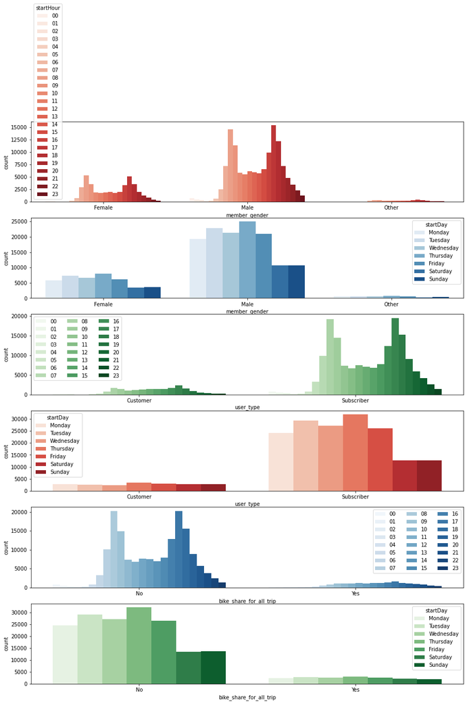

```python
plt.figure(figsize = [15, 20])

plt.subplot(6, 1, 1)
sb.countplot(data = fordBike, x = 'member_gender', hue = 'startHour', palette = 'Reds')
ax.legend(loc = 1, ncol = 3)

ax = plt.subplot(6, 1, 2)
sb.countplot(data = fordBike, x = 'member_gender', hue = 'startDay', palette = 'Blues')


ax = plt.subplot(6, 1, 3)
sb.countplot(data = fordBike, x = 'user_type', hue = 'startHour', palette = 'Greens')
ax.legend(loc = 2, ncol = 3)

ax = plt.subplot(6, 1, 4)
sb.countplot(data = fordBike, x = 'user_type', hue = 'startDay', palette = 'Reds')

ax = plt.subplot(6, 1, 5)
sb.countplot(data = fordBike, x = 'bike_share_for_all_trip', hue = 'startHour', palette = 'Blues')
ax.legend(loc = 1, ncol = 3)

ax = plt.subplot(6, 1, 6)
sb.countplot(data = fordBike, x = 'bike_share_for_all_trip', hue = 'startDay', palette = 'Greens')

plt.show()
```

we notice that the customer user's numbers of trips are closed to each other over the days on week whereas the subscriber users take a different levels of numbers of trips, Thursday has the higher one. in other word the costumer users have approximately the same numbers of trips on all days of the week. Also the number of trips which share the same bike for all trips dose not affected by different day on week.

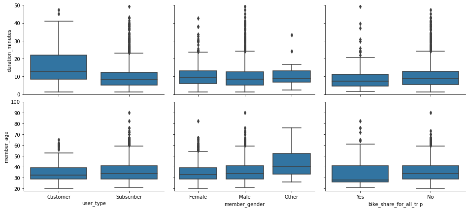

```python
categoric_vars=['user_type','member_gender','bike_share_for_all_trip']
samples = np.random.choice(fordBike.shape[0], 2000, replace = False)
fordBike_samp = fordBike.loc[samples,:]

def boxgrid(x, y, **kwargs):
    """ Quick hack for creating box plots with seaborn's PairGrid. """
    default_color = sb.color_palette()[0]
    sb.boxplot(x, y, color = default_color)

plt.figure(figsize = [10, 10])
g = sb.PairGrid(data = fordBike_samp, y_vars = ['duration_minutes', 'member_age'], x_vars = categoric_vars,
                size = 3, aspect = 1.5)
axes = g.axes
axes[0,0].set_ylim(0,50)#Remove outliers with high values
axes[1,0].set_ylim(18,100)#Remove outliers with high values
g.map(boxgrid)
plt.show();
```

From plot above it seams thst the costumer users are yonget than suscrber users also costumer users tends to have long trip duration than subscriber users.

### Talk about some of the relationships you observed in this part of the investigation. How did the feature(s) of interest vary with other features in the dataset?

> 2.the costumer users are yonget than suscrber users also costumer users tends to have long trip duration than suscrber users.

### Did you observe any interesting relationships between the other features (not the main feature(s) of interest)?

> 1.sharing bike for all trips and user type does not have a strong effect with memeber gender on number of trips. in other hand the user type is affected by whether the bike was sharing for all trips, There are no ccustomer share bike for all trips.

> 2.the customer user's numbers of trips are closed to each other over the days on week whereas the subscriber users take a different levels of numbers of trips, Thursday has the higher one. in other word the costumer users have approximately the same numbers of trips on all days of the week.

> 3.the number of trips which share the same bike for all trips dose not affected by different day on week.